# Regras de Associação - Instacart Market Basket Analysis

Este desafio como objetivo explorar o extenso conjunto de dados incluído no [Concurso Instacart Market Basket Analysis] (https://www.kaggle.com/c/instacart-market-basket-analysis), hospedado no Kaggle. O conjunto de dados contém mais de 3 milhões de transações de supermercado, compreendendo uma enorme variedade de produtos de diferentes departamentos. A concorrência lidava com a previsão de quais produtos encomendados anteriormente por um cliente seriam adicionados ao próximo pedido. Neste exercício, concentramo-nos na exploração de dados e na geração de regras de associação, que são informativas para estratégias de vendas, como as fornecidas pelos sistemas de recomendação. As regras de associação são uma das quatro tarefas fundamentais de aprendizado de máquina, juntamente com regressão, classificação e agrupamento. Faremos a geração de regras com base em duas coleções de dados: hábitos de compra (dia e hora, intervalo entre pedidos) e associação de produtos (quais produtos tendem a ser vendidos juntos)

## 1 Instalação e importação das bibliotecas

```python
!pip install apyori
```

```python
import os
import pandas as pd
import numpy as np
from apyori import apriori
from collections import Counter
from datetime import datetime
from itertools import combinations
import matplotlib.pyplot as plt
```

## 2 Obtenção dos dados

```python
from google.colab import drive
drive.mount('/content/gdrive')
```

```
Go to this URL in a browser: https://accounts.google.com/o/oauth2/auth?client_id=947318989803-6bn6qk8qdgf4n4g3pfee6491hc0brc4i.apps.googleusercontent.com&redirect_uri=urn%3aietf%3awg%3aoauth%3a2.0%3aoob&response_type=code&scope=email%20https%3a%2f%2fwww.googleapis.com%2fauth%2fdocs.test%20https%3a%2…

Enter your authorization code:
··········
```

```python
!mkdir data
```

```python
!cp /content/gdrive/My\ Drive/Cursos\ -\ recursos/Instacart/*.csv data
```

```python
os.chdir('data')
```

```python
os.listdir()
```

```
['order_products__prior.csv',
 'departments.csv',
 'orders.csv',
 'products.csv',
 'aisles.csv']
```

## 3 Carregando e inspecionando os arquivos

### `aisles.csv`

```python
aisles = pd.read_csv('aisles.csv')
```

```python
aisles.dtypes
```

```
aisle_id     int64
aisle       object
dtype: object
```

```python
aisles
```

|  | aisle_id | aisle |
| --- | --- | --- |
| 0 | 1 | prepared soups salads |
| 1 | 2 | specialty cheeses |
| 2 | 3 | energy granola bars |
| 3 | 4 | instant foods |
| 4 | 5 | marinades meat preparation |
| ... | ... | ... |
| 129 | 130 | hot cereal pancake mixes |
| 130 | 131 | dry pasta |
| 131 | 132 | beauty |
| 132 | 133 | muscles joints pain relief |
| 133 | 134 | specialty wines champagnes |

134 rows × 2 columns

```python
aisles.isna().sum(axis = 0)
```

```
aisle_id    0
aisle       0
dtype: int64
```

### `departments.csv`

```python
departments = pd.read_csv('departments.csv')
```

```python
departments.dtypes
```

```
department_id     int64
department       object
dtype: object
```

```python
departments
```

|  | department_id | department |
| --- | --- | --- |
| 0 | 1 | frozen |
| 1 | 2 | other |
| 2 | 3 | bakery |
| 3 | 4 | produce |
| 4 | 5 | alcohol |
| 5 | 6 | international |
| 6 | 7 | beverages |
| 7 | 8 | pets |
| 8 | 9 | dry goods pasta |
| 9 | 10 | bulk |
| 10 | 11 | personal care |
| 11 | 12 | meat seafood |
| 12 | 13 | pantry |
| 13 | 14 | breakfast |
| 14 | 15 | canned goods |
| 15 | 16 | dairy eggs |
| 16 | 17 | household |
| 17 | 18 | babies |
| 18 | 19 | snacks |
| 19 | 20 | deli |
| 20 | 21 | missing |

```python
departments.shape
```

```
(21, 2)
```

### `products.csv`

```python
products = pd.read_csv('products.csv')
```

```python
products.dtypes
```

```
product_id        int64
product_name     object
aisle_id          int64
department_id     int64
dtype: object
```

```python
products
```

|  | product_id | product_name | aisle_id | department_id |
| --- | --- | --- | --- | --- |
| 0 | 1 | Chocolate Sandwich Cookies | 61 | 19 |
| 1 | 2 | All-Seasons Salt | 104 | 13 |
| 2 | 3 | Robust Golden Unsweetened Oolong Tea | 94 | 7 |
| 3 | 4 | Smart Ones Classic Favorites Mini Rigatoni Wit... | 38 | 1 |
| 4 | 5 | Green Chile Anytime Sauce | 5 | 13 |
| ... | ... | ... | ... | ... |
| 49683 | 49684 | Vodka, Triple Distilled, Twist of Vanilla | 124 | 5 |
| 49684 | 49685 | En Croute Roast Hazelnut Cranberry | 42 | 1 |
| 49685 | 49686 | Artisan Baguette | 112 | 3 |
| 49686 | 49687 | Smartblend Healthy Metabolism Dry Cat Food | 41 | 8 |
| 49687 | 49688 | Fresh Foaming Cleanser | 73 | 11 |

49688 rows × 4 columns

```python
aisles[aisles['aisle_id'] == 61]
```

|  | aisle_id | aisle |
| --- | --- | --- |
| 60 | 61 | cookies cakes |

```python
departments[departments['department_id'] == 19]
```

|  | department_id | department |
| --- | --- | --- |
| 18 | 19 | snacks |

```python
products.describe()
```

|  | product_id | aisle_id | department_id |
| --- | --- | --- | --- |
| count | 49688.000000 | 49688.000000 | 49688.000000 |
| mean | 24844.500000 | 67.769582 | 11.728687 |
| std | 14343.834425 | 38.316162 | 5.850410 |
| min | 1.000000 | 1.000000 | 1.000000 |
| 25% | 12422.750000 | 35.000000 | 7.000000 |
| 50% | 24844.500000 | 69.000000 | 13.000000 |
| 75% | 37266.250000 | 100.000000 | 17.000000 |
| max | 49688.000000 | 134.000000 | 21.000000 |

```python
products.shape
```

```
(49688, 4)
```

```python
len(set(products.product_id))
```

```
49688
```

```python
products.isna().sum(axis = 0)
```

```
product_id       0
product_name     0
aisle_id         0
department_id    0
dtype: int64
```

### `orders.csv`

```python
orders = pd.read_csv('orders.csv')
```

```python
orders.dtypes
```

```
order_id                    int64
user_id                     int64
eval_set                   object
order_number                int64
order_dow                   int64
order_hour_of_day           int64
days_since_prior_order    float64
dtype: object
```

```python
orders
```

|  | order_id | user_id | eval_set | order_number | order_dow | order_hour_of_day | days_since_prior_order |
| --- | --- | --- | --- | --- | --- | --- | --- |
| 0 | 2539329 | 1 | prior | 1 | 2 | 8 | NaN |
| 1 | 2398795 | 1 | prior | 2 | 3 | 7 | 15.0 |
| 2 | 473747 | 1 | prior | 3 | 3 | 12 | 21.0 |
| 3 | 2254736 | 1 | prior | 4 | 4 | 7 | 29.0 |
| 4 | 431534 | 1 | prior | 5 | 4 | 15 | 28.0 |
| ... | ... | ... | ... | ... | ... | ... | ... |
| 3421078 | 2266710 | 206209 | prior | 10 | 5 | 18 | 29.0 |
| 3421079 | 1854736 | 206209 | prior | 11 | 4 | 10 | 30.0 |
| 3421080 | 626363 | 206209 | prior | 12 | 1 | 12 | 18.0 |
| 3421081 | 2977660 | 206209 | prior | 13 | 1 | 12 | 7.0 |
| 3421082 | 272231 | 206209 | train | 14 | 6 | 14 | 30.0 |

3421083 rows × 7 columns

```python
orders.shape
```

```
(3421083, 7)
```

```python
orders.eval_set.value_counts()
```

```
prior    3214874
train     131209
test       75000
Name: eval_set, dtype: int64
```

```python
orders = orders[orders.eval_set == 'prior']
orders.shape
```

```
(3214874, 7)
```

```python
orders.drop('eval_set', axis = 1, inplace=True)
```

```python
orders.describe()
```

|  | order_id | user_id | order_number | order_dow | order_hour_of_day | days_since_prior_order |
| --- | --- | --- | --- | --- | --- | --- |
| count | 3.214874e+06 | 3.214874e+06 | 3.214874e+06 | 3.214874e+06 | 3.214874e+06 | 3.008665e+06 |
| mean | 1.710827e+06 | 1.029701e+05 | 1.719107e+01 | 2.776364e+00 | 1.344347e+01 | 1.070724e+01 |
| std | 9.875206e+05 | 5.953411e+04 | 1.779950e+01 | 2.041806e+00 | 4.226246e+00 | 8.954180e+00 |
| min | 2.000000e+00 | 1.000000e+00 | 1.000000e+00 | 0.000000e+00 | 0.000000e+00 | 0.000000e+00 |
| 25% | 8.556832e+05 | 5.138500e+04 | 5.000000e+00 | 1.000000e+00 | 1.000000e+01 | 4.000000e+00 |
| 50% | 1.711120e+06 | 1.026620e+05 | 1.100000e+01 | 3.000000e+00 | 1.300000e+01 | 7.000000e+00 |
| 75% | 2.566034e+06 | 1.543720e+05 | 2.400000e+01 | 5.000000e+00 | 1.600000e+01 | 1.500000e+01 |
| max | 3.421083e+06 | 2.062090e+05 | 9.900000e+01 | 6.000000e+00 | 2.300000e+01 | 3.000000e+01 |

```python
len(set(orders.user_id))
```

```
206209
```

```python
orders.isna().sum(axis = 0)
```

```
order_id                       0
user_id                        0
order_number                   0
order_dow                      0
order_hour_of_day              0
days_since_prior_order    206209
dtype: int64
```

```python
orders.loc[orders.days_since_prior_order.isna()]
```

|  | order_id | user_id | order_number | order_dow | order_hour_of_day | days_since_prior_order |
| --- | --- | --- | --- | --- | --- | --- |
| 0 | 2539329 | 1 | 1 | 2 | 8 | NaN |
| 11 | 2168274 | 2 | 1 | 2 | 11 | NaN |
| 26 | 1374495 | 3 | 1 | 1 | 14 | NaN |
| 39 | 3343014 | 4 | 1 | 6 | 11 | NaN |
| 45 | 2717275 | 5 | 1 | 3 | 12 | NaN |
| ... | ... | ... | ... | ... | ... | ... |
| 3420930 | 969311 | 206205 | 1 | 4 | 12 | NaN |
| 3420934 | 3189322 | 206206 | 1 | 3 | 18 | NaN |
| 3421002 | 2166133 | 206207 | 1 | 6 | 19 | NaN |
| 3421019 | 2227043 | 206208 | 1 | 1 | 15 | NaN |
| 3421069 | 3154581 | 206209 | 1 | 3 | 11 | NaN |

206209 rows × 6 columns

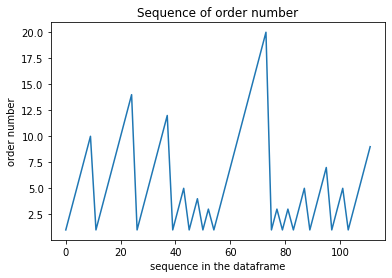

```python
plt.plot(orders.order_number[:100])
plt.title('Sequence of order number')
plt.xlabel('sequence in the dataframe')
plt.ylabel('order number');
```

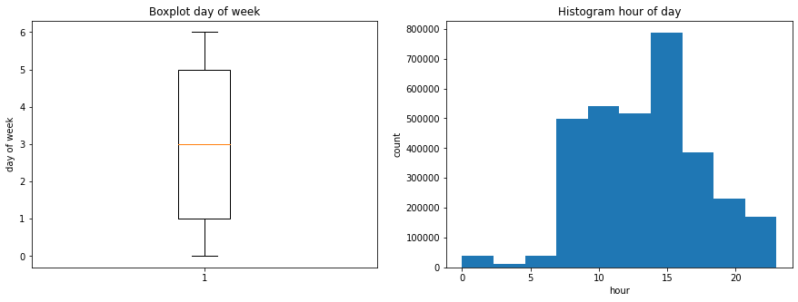

```python
fig, ax = plt.subplots(1, 2, figsize=(15, 5))
ax[0].boxplot(orders.order_dow)
ax[0].set_title('Boxplot day of week')
ax[0].set_ylabel('day of week')
ax[1].hist(orders.order_hour_of_day)
ax[1].set_title('Histogram hour of day')
ax[1].set_xlabel('hour')
ax[1].set_ylabel('count');
```

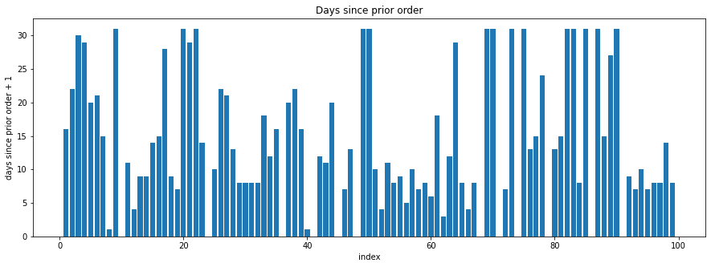

```python
plt.figure(figsize = (15,5))
plt.bar(range(100), orders.days_since_prior_order[:100] + 1)
plt.title('Days since prior order')
plt.xlabel('index')
plt.ylabel('days since prior order + 1');
```

### `order_products(__prior).csv`

```python
order_products = pd.read_csv('order_products__prior.csv')
```

```python
order_products.dtypes
```

```
order_id             int64
product_id           int64
add_to_cart_order    int64
reordered            int64
dtype: object
```

```python
order_products
```

|  | order_id | product_id | add_to_cart_order | reordered |
| --- | --- | --- | --- | --- |
| 0 | 2 | 33120 | 1 | 1 |
| 1 | 2 | 28985 | 2 | 1 |
| 2 | 2 | 9327 | 3 | 0 |
| 3 | 2 | 45918 | 4 | 1 |
| 4 | 2 | 30035 | 5 | 0 |
| ... | ... | ... | ... | ... |
| 32434484 | 3421083 | 39678 | 6 | 1 |
| 32434485 | 3421083 | 11352 | 7 | 0 |
| 32434486 | 3421083 | 4600 | 8 | 0 |
| 32434487 | 3421083 | 24852 | 9 | 1 |
| 32434488 | 3421083 | 5020 | 10 | 1 |

32434489 rows × 4 columns

```python
order_products.shape
```

```
(32434489, 4)
```

```python
len(set(order_products.order_id))
```

```
3214874
```

```python
order_products.isna().sum(axis=0)
```

```
order_id             0
product_id           0
add_to_cart_order    0
reordered            0
dtype: int64
```

## 4 Exploração dos dados

### `orders` dataframe

```python
orders_apriori = orders.copy()
```

```python
orders.head(11)
```

|  | order_id | user_id | order_number | order_dow | order_hour_of_day | days_since_prior_order |
| --- | --- | --- | --- | --- | --- | --- |
| 0 | 2539329 | 1 | 1 | 2 | 8 | NaN |
| 1 | 2398795 | 1 | 2 | 3 | 7 | 15.0 |
| 2 | 473747 | 1 | 3 | 3 | 12 | 21.0 |
| 3 | 2254736 | 1 | 4 | 4 | 7 | 29.0 |
| 4 | 431534 | 1 | 5 | 4 | 15 | 28.0 |
| 5 | 3367565 | 1 | 6 | 2 | 7 | 19.0 |
| 6 | 550135 | 1 | 7 | 1 | 9 | 20.0 |
| 7 | 3108588 | 1 | 8 | 1 | 14 | 14.0 |
| 8 | 2295261 | 1 | 9 | 1 | 16 | 0.0 |
| 9 | 2550362 | 1 | 10 | 4 | 8 | 30.0 |
| 11 | 2168274 | 2 | 1 | 2 | 11 | NaN |

#### User

```python
orders_by_user = orders.groupby('user_id')['order_number'].max()
```

```python
orders_by_user.head()
```

```
user_id
1    10
2    14
3    12
4     5
5     4
Name: order_number, dtype: int64
```

```python
order_products.head(15)
```

|  | order_id | product_id | add_to_cart_order | reordered |
| --- | --- | --- | --- | --- |
| 0 | 2 | 33120 | 1 | 1 |
| 1 | 2 | 28985 | 2 | 1 |
| 2 | 2 | 9327 | 3 | 0 |
| 3 | 2 | 45918 | 4 | 1 |
| 4 | 2 | 30035 | 5 | 0 |
| 5 | 2 | 17794 | 6 | 1 |
| 6 | 2 | 40141 | 7 | 1 |
| 7 | 2 | 1819 | 8 | 1 |
| 8 | 2 | 43668 | 9 | 0 |
| 9 | 3 | 33754 | 1 | 1 |
| 10 | 3 | 24838 | 2 | 1 |
| 11 | 3 | 17704 | 3 | 1 |
| 12 | 3 | 21903 | 4 | 1 |
| 13 | 3 | 17668 | 5 | 1 |
| 14 | 3 | 46667 | 6 | 1 |

```python
products_by_user = orders[['order_id', 'user_id']].merge(
    order_products[['order_id', 'add_to_cart_order']].groupby('order_id').max().rename({'add_to_cart_order': 'order_size'}, axis = 1),
                                                                                        on = 'order_id')
```

```python
products_by_user
```

|  | order_id | user_id | order_size |
| --- | --- | --- | --- |
| 0 | 2539329 | 1 | 5 |
| 1 | 2398795 | 1 | 6 |
| 2 | 473747 | 1 | 5 |
| 3 | 2254736 | 1 | 5 |
| 4 | 431534 | 1 | 8 |
| ... | ... | ... | ... |
| 3214869 | 2558525 | 206209 | 3 |
| 3214870 | 2266710 | 206209 | 9 |
| 3214871 | 1854736 | 206209 | 8 |
| 3214872 | 626363 | 206209 | 20 |
| 3214873 | 2977660 | 206209 | 9 |

3214874 rows × 3 columns

```python
products_by_user[products_by_user.order_id == 2]
```

|  | order_id | user_id | order_size |
| --- | --- | --- | --- |
| 3153247 | 2 | 202279 | 9 |

```python
products_by_user = products_by_user.drop('order_id', axis = 1).groupby('user_id')['order_size'].sum()
```

```python
products_by_user
```

```
user_id
1          59
2         195
3          88
4          18
5          37
         ...
206205     32
206206    285
206207    223
206208    677
206209    129
Name: order_size, Length: 206209, dtype: int64
```

```python
max(orders_by_user)
```

```
99
```

```python
min(orders_by_user)
```

```
3
```

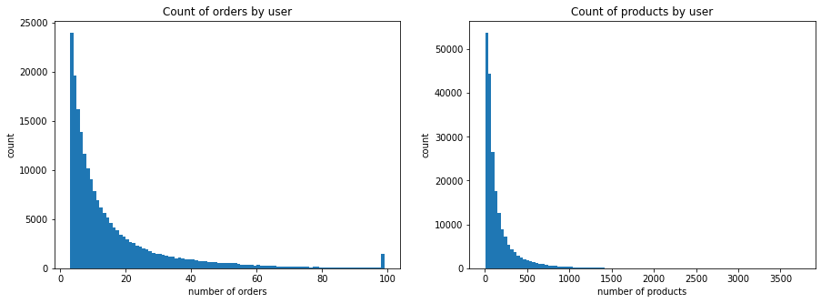

```python
fig, ax = plt.subplots(1, 2, figsize=(15,5))
ax[0].hist(orders_by_user, bins = max(orders_by_user) - min(orders_by_user))
ax[0].set_title('Count of orders by user')
ax[0].set_xlabel('number of orders')
ax[0].set_ylabel('count')

ax[1].hist(products_by_user, bins = 100)
ax[1].set_title('Count of products by user')
ax[1].set_xlabel('number of products')
ax[1].set_ylabel('count');
```

```python
orders_apriori.drop(['user_id', 'order_id'], axis = 1, inplace=True)
```

```python
orders_apriori.head()
```

|  | order_number | order_dow | order_hour_of_day | days_since_prior_order |
| --- | --- | --- | --- | --- |
| 0 | 1 | 2 | 8 | NaN |
| 1 | 2 | 3 | 7 | 15.0 |
| 2 | 3 | 3 | 12 | 21.0 |
| 3 | 4 | 4 | 7 | 29.0 |
| 4 | 5 | 4 | 15 | 28.0 |

#### Order number

```python
orders.head()
```

|  | order_id | user_id | order_number | order_dow | order_hour_of_day | days_since_prior_order |
| --- | --- | --- | --- | --- | --- | --- |
| 0 | 2539329 | 1 | 1 | 2 | 8 | NaN |
| 1 | 2398795 | 1 | 2 | 3 | 7 | 15.0 |
| 2 | 473747 | 1 | 3 | 3 | 12 | 21.0 |
| 3 | 2254736 | 1 | 4 | 4 | 7 | 29.0 |
| 4 | 431534 | 1 | 5 | 4 | 15 | 28.0 |

```python
orders_by_order_number = orders.order_number.value_counts()
orders_by_order_number
```

```
1     206209
2     206209
3     206209
4     182223
5     162633
       ...
95      1592
96      1525
97      1471
98      1421
99      1374
Name: order_number, Length: 99, dtype: int64
```

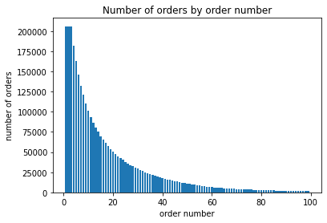

```python
plt.bar(orders_by_order_number.index, orders_by_order_number)
plt.title('Number of orders by order number')
plt.xlabel('order number')
plt.ylabel('number of orders');
```

```python
def order_number_categorical(order_number):
  if order_number in range(3):
    return 'order_number_1-3'
  if order_number in range(3, 5):
    return 'order_number_4-5'
  if order_number in range(5, 10):
    return 'order_number_6-10'
  if order_number in range(10, 20):
    return 'order_number_11-20'
  if order_number in range(20, 40):
    return 'order_number_21-40'
  if order_number in range(40, 60):
    return 'order_number_41-60'
  if order_number >= 60:
    return 'order_number_60+'
```

```python
orders_apriori.order_number = orders_apriori.order_number.map(order_number_categorical)
```

```python
orders_apriori.head()
```

|  | order_number | order_dow | order_hour_of_day | days_since_prior_order |
| --- | --- | --- | --- | --- |
| 0 | order_number_1-3 | 2 | 8 | NaN |
| 1 | order_number_1-3 | 3 | 7 | 15.0 |
| 2 | order_number_4-5 | 3 | 12 | 21.0 |
| 3 | order_number_4-5 | 4 | 7 | 29.0 |
| 4 | order_number_6-10 | 4 | 15 | 28.0 |

#### Day of week

```python
orders_by_dow = orders.order_dow.value_counts()
orders_by_dow
```

```
0    557772
1    556705
2    441955
5    425982
6    418848
3    412400
4    401212
Name: order_dow, dtype: int64
```

```python
products_by_dow = orders[['order_id', 'order_dow']].merge(
    order_products[['order_id', 'add_to_cart_order']].groupby('order_id').max().rename({'add_to_cart_order': 'order_size'}, axis = 1),
    on = 'order_id'
)
```

```python
products_by_dow = products_by_dow.drop('order_id', axis=1).groupby('order_dow')['order_size'].sum()
```

```python
products_by_dow
```

```
order_dow
0    6209666
1    5665856
2    4217798
3    3844117
4    3787215
5    4209533
6    4500304
Name: order_size, dtype: int64
```

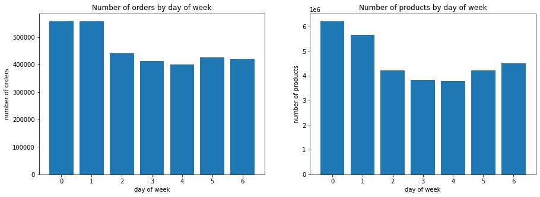

```python
fig, ax = plt.subplots(1, 2, figsize=(15, 5))
ax[0].bar(orders_by_dow.index, orders_by_dow)
ax[0].set_title('Number of orders by day of week')
ax[0].set_xlabel('day of week')
ax[0].set_ylabel('number of orders')

ax[1].bar(products_by_dow.index, products_by_dow)
ax[1].set_title('Number of products by day of week')
ax[1].set_xlabel('day of week')
ax[1].set_ylabel('number of products');
```

```python
def dow_categorical(dow):
  if dow in [0, 1]:
    return 'weekend'
  else:
    return 'weekday'
```

```python
orders_apriori.order_dow = orders_apriori.order_dow.map(dow_categorical)
orders_apriori.head()
```

|  | order_number | order_dow | order_hour_of_day | days_since_prior_order |
| --- | --- | --- | --- | --- |
| 0 | order_number_1-3 | weekday | 8 | NaN |
| 1 | order_number_1-3 | weekday | 7 | 15.0 |
| 2 | order_number_4-5 | weekday | 12 | 21.0 |
| 3 | order_number_4-5 | weekday | 7 | 29.0 |
| 4 | order_number_6-10 | weekday | 15 | 28.0 |

#### Hour of day

```python
orders_by_hour = orders.order_hour_of_day.value_counts()
orders_by_hour
```

```
10    271885
11    268006
15    266132
14    265556
13    261174
12    256206
16    255949
9     243496
17    214080
18    170998
8     168321
19    131620
20     98109
7      86656
21     73436
22     57540
23     37613
6      28792
0      21372
1      11596
5       8972
2       7070
4       5175
3       5120
Name: order_hour_of_day, dtype: int64
```

```python
products_by_hour = orders[['order_id', 'order_hour_of_day']].merge(
    order_products[['order_id', 'add_to_cart_order']].groupby('order_id').max().rename({'add_to_cart_order': 'order_size'}, axis = 1),
    on = 'order_id'
)
products_by_hour = products_by_hour.drop('order_id', axis = 1).groupby('order_hour_of_day')['order_size'].sum()
```

```python
products_by_hour
```

```
order_hour_of_day
0      218948
1      115786
2       69434
3       51321
4       53283
5       88062
6      290795
7      891937
8     1719973
9     2456713
10    2764426
11    2738582
12    2620847
13    2663292
14    2691548
15    2664533
16    2537458
17    2089465
18    1637923
19    1259401
20     977038
21     796370
22     634734
23     402620
Name: order_size, dtype: int64
```

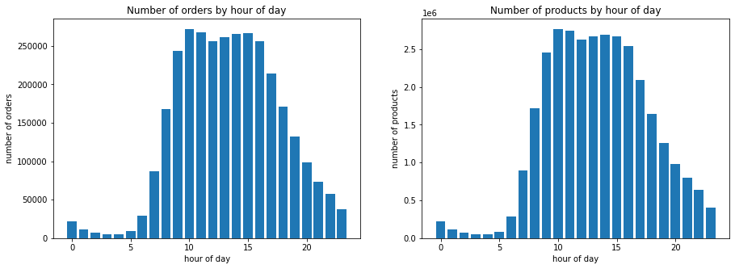

```python
fig, ax = plt.subplots(1, 2, figsize=(15, 5))
ax[0].bar(orders_by_hour.index, orders_by_hour)
ax[0].set_title('Number of orders by hour of day')
ax[0].set_xlabel('hour of day')
ax[0].set_ylabel('number of orders')

ax[1].bar(products_by_hour.index, products_by_hour)
ax[1].set_title('Number of products by hour of day')
ax[1].set_xlabel('hour of day')
ax[1].set_ylabel('number of products');
```

```python
def hour_categorical(hour):
  if hour in range(7):
    return 'early_hours'
  if hour in range(7,10):
    return 'hour_' + str(hour)
  if hour in range(10, 17):
    return 'peak_hours'
  if hour in range(17, 24):
    return 'hour_' + str(hour)
```

```python
orders_apriori.order_hour_of_day = orders_apriori.order_hour_of_day.map(hour_categorical)
orders_apriori.head()
```

|  | order_number | order_dow | order_hour_of_day | days_since_prior_order |
| --- | --- | --- | --- | --- |
| 0 | order_number_1-3 | weekday | hour_8 | NaN |
| 1 | order_number_1-3 | weekday | hour_7 | 15.0 |
| 2 | order_number_4-5 | weekday | peak_hours | 21.0 |
| 3 | order_number_4-5 | weekday | hour_7 | 29.0 |
| 4 | order_number_6-10 | weekday | peak_hours | 28.0 |

#### Intervalo entre os pedidos

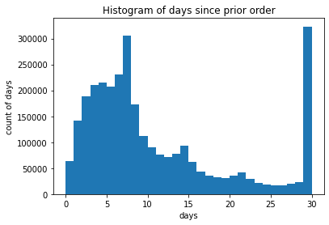

```python
plt.hist(orders.days_since_prior_order, bins = 30)
plt.title('Histogram of days since prior order')
plt.xlabel('days')
plt.ylabel('count of days');
```

```python
def interval_categorical(interval):
  if np.isnan(interval):
    return 'first_order'
  elif interval in [7, 14, 21]:
    return 'interval_weekly'
  elif interval == 30:
    return 'interval_30+'
  else:
    return 'interval_others'
```

```python
orders_apriori.days_since_prior_order = orders_apriori.days_since_prior_order.map(interval_categorical)
orders_apriori.head()
```

|  | order_number | order_dow | order_hour_of_day | days_since_prior_order |
| --- | --- | --- | --- | --- |
| 0 | order_number_1-3 | weekday | hour_8 | first_order |
| 1 | order_number_1-3 | weekday | hour_7 | interval_others |
| 2 | order_number_4-5 | weekday | peak_hours | interval_weekly |
| 3 | order_number_4-5 | weekday | hour_7 | interval_others |
| 4 | order_number_6-10 | weekday | peak_hours | interval_others |

### `order_products` dataframe

#### Produtos recomprados (reordered)

```python
products_id_to_name = {k: v for k, v in zip(products.product_id, products.product_name)}
print(products_id_to_name)
```

```
{1: 'Chocolate Sandwich Cookies', 2: 'All-Seasons Salt', 3: 'Robust Golden Unsweetened Oolong Tea', 4: 'Smart Ones Classic Favorites Mini Rigatoni With Vodka Cream Sauce', 5: 'Green Chile Anytime Sauce', 6: 'Dry Nose Oil', 7: 'Pure Coconut Water With Orange', 8: "Cut Russet Potatoes Steam N' Mash", …
```

```python
order_products_names = order_products.copy()
order_products_names['product_name'] = order_products_names.product_id.map(lambda x: products_id_to_name[x])
order_products_names
```

|  | order_id | product_id | add_to_cart_order | reordered | product_name |
| --- | --- | --- | --- | --- | --- |
| 0 | 2 | 33120 | 1 | 1 | Organic Egg Whites |
| 1 | 2 | 28985 | 2 | 1 | Michigan Organic Kale |
| 2 | 2 | 9327 | 3 | 0 | Garlic Powder |
| 3 | 2 | 45918 | 4 | 1 | Coconut Butter |
| 4 | 2 | 30035 | 5 | 0 | Natural Sweetener |
| ... | ... | ... | ... | ... | ... |
| 32434484 | 3421083 | 39678 | 6 | 1 | Free & Clear Natural Dishwasher Detergent |
| 32434485 | 3421083 | 11352 | 7 | 0 | Organic Mini Sandwich Crackers Peanut Butter |
| 32434486 | 3421083 | 4600 | 8 | 0 | All Natural French Toast Sticks |
| 32434487 | 3421083 | 24852 | 9 | 1 | Banana |
| 32434488 | 3421083 | 5020 | 10 | 1 | Organic Sweet & Salty Peanut Pretzel Granola ... |

32434489 rows × 5 columns

```python
reorder_proportion = pd.crosstab(order_products_names.product_name, order_products_names.reordered)
reorder_proportion
```

| reordered product_name | 0 | 1 |
| --- | --- | --- |
| #2 Coffee Filters | 520 | 257 |
| #2 Cone White Coffee Filters | 10 | 3 |
| #2 Mechanical Pencils | 8 | 0 |
| #4 Natural Brown Coffee Filters | 152 | 89 |
| & Go! Hazelnut Spread + Pretzel Sticks | 77 | 87 |
| ... | ... | ... |
| with Xylitol Unwrapped Original Flavor 50 Sticks Sugar Free Gum | 20 | 17 |
| with Xylitol Unwrapped Spearmint 50 Sticks Sugar Free Gum | 36 | 19 |
| with Xylitol Watermelon Twist 18 Sticks Sugar Free Gum | 37 | 31 |
| with a Splash of Mango Coconut Water | 17 | 6 |
| with a Splash of Pineapple Coconut Water | 28 | 25 |

49677 rows × 2 columns

```python
reorder_proportion.sort_values(by = 0, ascending=False)
```

| reordered product_name | 0 | 1 |
| --- | --- | --- |
| Banana | 73956 | 398609 |
| Bag of Organic Bananas | 63537 | 315913 |
| Organic Strawberries | 58838 | 205845 |
| Organic Baby Spinach | 55037 | 186884 |
| Large Lemon | 46402 | 106255 |
| ... | ... | ... |
| Brut Prosecco | 1 | 0 |
| Smooth & Silky Head and Shoulders Smooth & Silky 2-in-1 Dandruff Shampoo + Conditioner 13.5 Fl Oz Female Hair Care | 1 | 0 |
| Gluten Free Pantry Sugar Cookie Mix | 1 | 1 |
| Organic Chickpea Fusilli Pasta | 1 | 0 |
| Midnight Brownie Cookies | 1 | 0 |

49677 rows × 2 columns

```python
reorder_proportion.sort_values(by = 1, ascending=False)
```

| reordered product_name | 0 | 1 |
| --- | --- | --- |
| Banana | 73956 | 398609 |
| Bag of Organic Bananas | 63537 | 315913 |
| Organic Strawberries | 58838 | 205845 |
| Organic Baby Spinach | 55037 | 186884 |
| Organic Hass Avocado | 43453 | 170131 |
| ... | ... | ... |
| Decorating Green Cake Icing | 21 | 0 |
| Lemon Ice Tea Liquid | 4 | 0 |
| Decorating Gel, Red | 7 | 0 |
| Decorating Gel White | 11 | 0 |
| Cld/Flu Van Chrry | 1 | 0 |

49677 rows × 2 columns

```python
reorder_proportion['total'] = reorder_proportion.sum(axis = 1)
reorder_proportion['0.perc'] = reorder_proportion[0] / reorder_proportion['total']
reorder_proportion['1.perc'] = reorder_proportion[1] / reorder_proportion['total']
```

```python
reorder_proportion.head()
```

| reordered product_name | 0 | 1 | total | 0.perc | 1.perc |
| --- | --- | --- | --- | --- | --- |
| #2 Coffee Filters | 520 | 257 | 777 | 0.669241 | 0.330759 |
| #2 Cone White Coffee Filters | 10 | 3 | 13 | 0.769231 | 0.230769 |
| #2 Mechanical Pencils | 8 | 0 | 8 | 1.000000 | 0.000000 |
| #4 Natural Brown Coffee Filters | 152 | 89 | 241 | 0.630705 | 0.369295 |
| & Go! Hazelnut Spread + Pretzel Sticks | 77 | 87 | 164 | 0.469512 | 0.530488 |

```python
reorder_proportion.sort_values(by = ['0.perc', 'total'], ascending = False)[['0.perc', 'total']]
```

| reordered product_name | 0.perc | total |
| --- | --- | --- |
| Vicks DayQuil and NyQuil Cold & Flu Relief Combo | 1.000000 | 88 |
| Organic Castor Oil Skin Care | 1.000000 | 67 |
| Organic Whole Rosemary | 1.000000 | 63 |
| Lemon Verbena Scent Glass Cleaner | 1.000000 | 53 |
| Organic Lemongrass | 1.000000 | 52 |
| ... | ... | ... |
| Soy Powder Infant Formula | 0.085714 | 35 |
| Chocolate Love Bar | 0.079208 | 101 |
| Orange Energy Shots | 0.076923 | 13 |
| Serenity Ultimate Extrema Overnight Pads | 0.068966 | 87 |
| Raw Veggie Wrappers | 0.058824 | 68 |

49677 rows × 2 columns

```python
reorder_proportion.sort_values(by = ['1.perc', 'total'], ascending = False)[['1.perc', 'total']]
```

| reordered product_name | 1.perc | total |
| --- | --- | --- |
| Raw Veggie Wrappers | 0.941176 | 68 |
| Serenity Ultimate Extrema Overnight Pads | 0.931034 | 87 |
| Orange Energy Shots | 0.923077 | 13 |
| Chocolate Love Bar | 0.920792 | 101 |
| Soy Powder Infant Formula | 0.914286 | 35 |
| ... | ... | ... |
| Vitality Chicken Breasts with Flaxseed & Vitamins Dog Treats | 0.000000 | 1 |
| Vitamin D Gummies | 0.000000 | 1 |
| Wicked Good No-Fry Wing Marinade | 0.000000 | 1 |
| Yellow Fish Breading | 0.000000 | 1 |
| Zingz Queso Fundido Baked Snack Crackers | 0.000000 | 1 |

49677 rows × 2 columns

```python
reorder_proportion.total.sort_values(ascending=False)
```

```
product_name
Banana                                                                                 472565
Bag of Organic Bananas                                                                 379450
Organic Strawberries                                                                   264683
Organic Baby Spinach                                                                   241921
Organic Hass Avocado                                                                   213584
                                                                                        ...
Lndbrg White Quinoa 16 Z                                                                    1
Homestlye Cornbread Stuffing                                                                1
Indoor & Outdoor Allergies, Allergy & Congestion, 24 Hour, Extended Release Tablets         1
Orange Recharge                                                                             1
Vitamin D Gummies                                                                           1
Name: total, Length: 49677, dtype: int64
```

#### Produtos não comprados

```python
products_bought = sorted(order_products.product_id.unique())
print(len(products_bought), len(products))
```

```
49677 49688
```

```python
products_not_bought = list(products.product_id[~products.product_id.isin(products_bought)])
products_not_bought
```

```
[3630, 3718, 7045, 25383, 27499, 36233, 37703, 43725, 45971, 46625, 49540]
```

```python
[products_id_to_name[product] for product in products_not_bought]
```

```
['Protein Granola Apple Crisp',
 'Wasabi Cheddar Spreadable Cheese',
 'Unpeeled Apricot Halves in Heavy Syrup',
 'Chocolate Go Bites',
 'Non-Dairy Coconut Seven Layer Bar',
 'Water With Electrolytes',
 'Ultra Sun Blossom Liquid 90 loads Fabric Enhancers',
 'Sweetart Jelly Beans',
 '12 Inch Taper Candle White',
 'Single Barrel Kentucky Straight Bourbon Whiskey',
 'Pure Squeezed  Lemonade']
```

```python
products_not_registered = list(pd.Series(products_bought)[~pd.Series(products_bought).isin(products.product_id)])
print(len(products_not_registered), products_not_registered)
```

```
0 []
```

#### Tamanho da cesta de compras

```python
cart_size = order_products.groupby('order_id')['add_to_cart_order'].max()
cart_size
```

```
order_id
2           9
3           8
4          13
5          26
6           3
           ..
3421079     1
3421080     9
3421081     7
3421082     7
3421083    10
Name: add_to_cart_order, Length: 3214874, dtype: int64
```

```python
cart_size = cart_size.value_counts()
cart_size
```

```
5      228330
6      227675
4      222081
7      220006
3      207027
        ...
112         1
105         1
94          1
90          1
145         1
Name: add_to_cart_order, Length: 113, dtype: int64
```

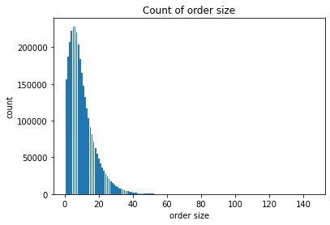

```python
plt.bar(cart_size.index, cart_size)
plt.title('Count of order size')
plt.xlabel('order size')
plt.ylabel('count');
```

#### Produtos mais frequentes

```python
order_products_names
```

|  | order_id | product_id | add_to_cart_order | reordered | product_name |
| --- | --- | --- | --- | --- | --- |
| 0 | 2 | 33120 | 1 | 1 | Organic Egg Whites |
| 1 | 2 | 28985 | 2 | 1 | Michigan Organic Kale |
| 2 | 2 | 9327 | 3 | 0 | Garlic Powder |
| 3 | 2 | 45918 | 4 | 1 | Coconut Butter |
| 4 | 2 | 30035 | 5 | 0 | Natural Sweetener |
| ... | ... | ... | ... | ... | ... |
| 32434484 | 3421083 | 39678 | 6 | 1 | Free & Clear Natural Dishwasher Detergent |
| 32434485 | 3421083 | 11352 | 7 | 0 | Organic Mini Sandwich Crackers Peanut Butter |
| 32434486 | 3421083 | 4600 | 8 | 0 | All Natural French Toast Sticks |
| 32434487 | 3421083 | 24852 | 9 | 1 | Banana |
| 32434488 | 3421083 | 5020 | 10 | 1 | Organic Sweet & Salty Peanut Pretzel Granola ... |

32434489 rows × 5 columns

```python
add_to_cart = pd.crosstab(order_products_names.product_name, order_products_names.add_to_cart_order)
add_to_cart
```

| add_to_cart_order product_name | 1 | 2 | 3 | 4 | 5 | 6 | 7 | 8 | 9 | 10 | 11 | 12 | 13 | 14 | 15 | 16 | 17 | 18 | 19 | 20 | 21 | 22 | 23 | 24 | 25 | 26 | 27 | 28 | 29 | … |
| --- | --- | --- | --- | --- | --- | --- | --- | --- | --- | --- | --- | --- | --- | --- | --- | --- | --- | --- | --- | --- | --- | --- | --- | --- | --- | --- | --- | --- | --- | --- |
| #2 Coffee Filters | 86 | 61 | 56 | 52 | 38 | 42 | 41 | 50 | 41 | 40 | 40 | 33 | 24 | 16 | 25 | 26 | 10 | 12 | 10 | 11 | 9 | 7 | 8 | 5 | 5 | 4 | 2 | 5 | 1 | … |
| #2 Cone White Coffee Filters | 4 | 0 | 1 | 0 | 2 | 0 | 0 | 0 | 1 | 2 | 1 | 0 | 0 | 0 | 0 | 0 | 0 | 1 | 0 | 0 | 1 | 0 | 0 | 0 | 0 | 0 | 0 | 0 | 0 | … |
| #2 Mechanical Pencils | 3 | 0 | 1 | 0 | 1 | 0 | 0 | 0 | 0 | 0 | 0 | 0 | 0 | 0 | 0 | 1 | 1 | 1 | 0 | 0 | 0 | 0 | 0 | 0 | 0 | 0 | 0 | 0 | 0 | … |
| #4 Natural Brown Coffee Filters | 24 | 15 | 12 | 18 | 16 | 16 | 13 | 9 | 11 | 6 | 8 | 8 | 12 | 9 | 7 | 9 | 10 | 4 | 2 | 2 | 5 | 1 | 2 | 3 | 3 | 0 | 2 | 2 | 2 | … |
| & Go! Hazelnut Spread + Pretzel Sticks | 12 | 7 | 9 | 9 | 12 | 12 | 12 | 9 | 13 | 9 | 4 | 3 | 3 | 3 | 7 | 5 | 1 | 5 | 4 | 4 | 1 | 1 | 0 | 2 | 2 | 1 | 3 | 1 | 1 | … |
| ... | ... | ... | ... | ... | ... | ... | ... | ... | ... | ... | ... | ... | ... | ... | ... | ... | ... | ... | ... | ... | ... | ... | ... | ... | ... | ... | ... | ... | ... | … |
| with Xylitol Unwrapped Original Flavor 50 Sticks Sugar Free Gum | 3 | 5 | 2 | 3 | 5 | 5 | 2 | 2 | 3 | 1 | 1 | 3 | 1 | 0 | 0 | 0 | 0 | 1 | 0 | 0 | 0 | 0 | 0 | 0 | 0 | 0 | 0 | 0 | 0 | … |
| with Xylitol Unwrapped Spearmint 50 Sticks Sugar Free Gum | 5 | 5 | 4 | 1 | 6 | 6 | 3 | 1 | 3 | 3 | 2 | 4 | 0 | 1 | 0 | 2 | 3 | 0 | 2 | 1 | 0 | 0 | 0 | 0 | 0 | 0 | 0 | 1 | 0 | … |
| with Xylitol Watermelon Twist 18 Sticks Sugar Free Gum | 6 | 4 | 7 | 5 | 7 | 8 | 9 | 6 | 2 | 1 | 2 | 1 | 2 | 0 | 0 | 1 | 0 | 1 | 1 | 0 | 0 | 0 | 1 | 1 | 1 | 1 | 0 | 0 | 0 | … |
| with a Splash of Mango Coconut Water | 0 | 3 | 2 | 0 | 1 | 3 | 0 | 0 | 2 | 1 | 0 | 1 | 2 | 1 | 2 | 1 | 0 | 0 | 0 | 0 | 0 | 0 | 0 | 0 | 0 | 0 | 1 | 0 | 0 | … |
| with a Splash of Pineapple Coconut Water | 4 | 8 | 8 | 3 | 3 | 2 | 2 | 4 | 3 | 1 | 3 | 2 | 1 | 0 | 0 | 2 | 1 | 0 | 1 | 2 | 0 | 1 | 1 | 0 | 0 | 1 | 0 | 0 | 0 | … |

49677 rows × 145 columns

```python
for i in range(1,6):
  print('ORDER = ', i)
  print(add_to_cart.sort_values(by = i, ascending=False)[i][:5])
  print('\n')
```

```
ORDER =  1
product_name
Banana                    110916
Bag of Organic Bananas     78988
Organic Whole Milk         30927
Organic Strawberries       27975
Organic Hass Avocado       24116
Name: 1, dtype: int64


ORDER =  2
product_name
Banana                    80432
Bag of Organic Bananas    64337
Organic Strawberries      29754
Organic Hass Avocado      26517
Organic Baby Spinach      25025
Name: 2, dtype: int64


ORDER =  3
product_name
Banana                    58577
Bag of Organic Bananas    48972
Organic Strawberries      27809
Organic Baby Spinach      24297
Organic Hass Avocado      24212
Name: 3, dtype: int64


ORDER =  4
product_name
Banana                    43653
Bag of Organic Bananas    36955
Organic Strawberries      25242
Organic Baby Spinach      22733
Organic Hass Avocado      21001
Name: 4, dtype: int64


ORDER =  5
product_name
Banana                    33647
Bag of Organic Bananas    28897
Organic Strawberries      22137
Organic Baby Spinach      20308
Organic Hass Avocado      18275
Name: 5, dtype: int64
```